# BIOM612 Experimental Design

Dorothy Hammond, PhD MPH and Deanne Taylor PhD

2/1/2018

# Setup

Packages to install this week:

- corrgram
- epitools

# Introduction

This week’s lab focuses rather heavily on biomedical statistics, which strategies do not always overlap with statistical design for laboratory-based experiments. We will revisit additional topics in experimental design considerations for laboratory experiments in following laboratories.

For now, we’ll focus on getting you acquainted with biomedical approaches to statistics. Biomedical statistics often take different approaches to experimental design than you would have encountered in typical statistics courses. Because biostatistics methods are often employed in human subject data, it’s good to introduce you to these concepts, especially odds ratios and relative risks.

Additional topics in biostatistics, such as survival curves and treatment effecs will also be explored in future labs and lectures in this course. However, to get a good handle on this topic, you should consider a full biostatistics course.

# Risks and Odds

A well designed biomedical study is one in which the researcher has taken the time and made the effort to organize the study/experiment properly to ensure that the right type of data is generated, and there is enough of the data available to answer the relevant question. The researcher also has to consider other unmeasured/unassessed varianbles that may influence the interpretation of the result.

In class we introduced a few types of experimental designs, and looked at the different factors that may confound our resulting association obtained. This lab will forcus on trying your hands on analyzing risk, odds, and correlation analysis using R.

We will be using both full functions to do the calculations as well as R packages. We often encounter situations in which an R package isn’t sufficient to complete an analysis, so we give examples and can point to resources that have full functions available. Additionally, writing a function allows you to use the same tool for different analysis with little to no change in code.

For analyses, we’ll use the R package epitools, which you should install.

The full functions for RR and Odds Ratios are from this webpage by Avril Coghlan:

http://a-little-book-of-r-for-biomedical-statistics.readthedocs.io/en/latest/src/biomedicalstats.html

Please bookmark that webpage for your future reference. We do not have time in this course to cover all the topics there, but you may find the additional topics interesting or useful for your research, and the background you get from this course should allow you to more quickly pick up and learn them.

## Calculating Relative Risks / Risk Ratio for a Study

Let us take a cohort study as our first example. A cohort study is a study design in which you have information on a study population who were exposed to “something” of interest (treatment, environmental or other exposures) and also on whether the same individuals in the study population have a certain disease or not (outcome). Your data should look something like this

```r
myDataMatrix <- matrix(c(2250,6222,1231,14897), nrow = 2, byrow = TRUE)
colnames(myDataMatrix) <- c("Disease-Yes", "Disease-No")
rownames(myDataMatrix) <- c( "Exposed", "Unexposed")
print(myDataMatrix)
```

```
##           Disease-Yes Disease-No
## Exposed          2250       6222
## Unexposed        1231      14897
```

# Proportion tests and 2x2 tables.

Going back to prop.test(), we can use the 2x2 table we generated in myData Matrix to report the proportion test:

```r
#2x2 data transformed to a table of proportions, just to see:
prop.table(myDataMatrix)
```

```
##           Disease-Yes Disease-No
## Exposed    0.09146341  0.2529268
## Unexposed  0.05004065  0.6055691
```

```r
pt_test<-prop.test(myDataMatrix)
pt_test
```

```
##
##  2-sample test for equality of proportions with continuity
##  correction
##
## data:  myDataMatrix
## X-squared = 1636.1, df = 1, p-value < 2.2e-16
## alternative hypothesis: two.sided
## 95 percent confidence interval:
##  0.1789055 0.1996022
## sample estimates:
##     prop 1     prop 2
## 0.26558074 0.07632688
```

The 95% confidence interval in prop.table does not cross zero, so we can be confident that there is a difference in proportions. What is the actual proportional difference in exposure for those who had disease?

```r
pt_test<-prop.test(myDataMatrix)
pt_diff<-pt_test$estimate[1] - pt_test$estimate[2]
pt_diff
```

```
##    prop 1
## 0.1892539
```

The difference between the two proportions is about 19%.

As a rule of thumb, proportional differences are often reported as risk ratios in biomedical statistics.

# Calculate Relative Risk / Risk Ratio

Calculating the relative risk (RR) of having disease given exposure is the probability of having the disease for people who were exposed to the treatment or environmental factor, divided by the probability of having the disease for people who were not exposed to that treatment or environmental factor.

## Function for Risk Ratios

```r
calcRelativeRisk <- function(mymatrix, alpha=0.05, referencerow=2)
{
     numrow <- nrow(mymatrix)
     myrownames <- rownames(mymatrix)
     for (i in 1:numrow)
     {
        rowname <- myrownames[i]
        DiseaseUnexposed <- mymatrix[referencerow,1]
        ControlUnexposed <- mymatrix[referencerow,2]
        if (i != referencerow)
        {
           DiseaseExposed <- mymatrix[i,1]
           ControlExposed <- mymatrix[i,2]
           totExposed <- DiseaseExposed + ControlExposed
           totUnexposed <- DiseaseUnexposed + ControlUnexposed
           probDiseaseGivenExposed <- DiseaseExposed/totExposed
           probDiseaseGivenUnexposed <- DiseaseUnexposed/totUnexposed

           # calculate the relative risk
           relativeRisk <- probDiseaseGivenExposed/probDiseaseGivenUnexposed
           print(paste("category =", rowname, ", relative risk = ",relativeRisk))

           # calculate a confidence interval
           confidenceLevel <- (1 - alpha)*100
           sigma <- sqrt((1/DiseaseExposed) - (1/totExposed) +
                         (1/DiseaseUnexposed) - (1/totUnexposed))
           # sigma is the standard error of estimate of log of relative risk
           z <- qnorm(1-(alpha/2))
           lowervalue <- relativeRisk * exp(-z * sigma)
           uppervalue <- relativeRisk * exp( z * sigma)
           print(paste("category =", rowname, ", ", confidenceLevel,
              "% confidence interval = [",lowervalue,",",uppervalue,"]"))
        }
     }
  }
```

## Testing the RR functions

To use the function:

```r
calcRelativeRisk(myDataMatrix,alpha = 0.05)
```

```
## [1] "category = Exposed , relative risk =  3.47951756212849"
## [1] "category = Exposed ,  95 % confidence interval = [ 3.26277996860317 , 3.71065244413148 ]"
```

Compare to the epitools risk ratio:

```r
library(epitools)

#rev means reversing "b"oth columns/rows to match inputs into our above function.  This is because epitools expects the reversed input from what we start with. The results will be similar to our function.

rr_epi <- riskratio(myDataMatrix, rev="b", conf.level = 0.95)
rr_epi$measure
```

```
##                         NA
## risk ratio with 95% C.I. estimate   lower    upper
##                Unexposed 1.000000      NA       NA
##                Exposed   3.479518 3.26278 3.710652
```

In earlier tests, we expect our confidence intervals for a difference to not overlap 0 to reject the null.

Recall this line in our function in chunk 3:

relRisk <- probDiseaseGivenExposed/probDiseaseGivenUnexposed

If the quantities (exposed/unexposed) are equal the null will give a value of 1. In this case, we have to find a confidence interval that does not overlap 1 to reject the null because we are testing proportions.

In our case of myDataMatrix, the confidence intervals don’t overlap the number 1, so we can assume the population proportions are different.

How do we represent this?

pct increase (rr > 1) = (RR CI lower bound – 1) x 100

When the RR is less than 1, so there’s a decrease in risk, the risk ratio bound can be calculated by:

pct decrease (rr < 1) = (1 – RR CI upper bound) x 100

Based on the lower confidence bound, we can state that the risk of disease after exposure is at least (3.26 -1 )*100 = 226% higher in the exposed group.

# Odds Ratio

Recall that a probability of 0.80 is equivalent to 80% chance of an event occuring. Odds express the likelihood of a success given a certain number of trials. To express an 80% chance of occurring to odds, we can divide the difference from 1:

$$\frac{0.80}{(1-0.80)}= \frac{0.80}{0.20} = 4$$

Therefore, the odds of success are 4 to 1, where for every four successes we can expect one failure.

## Function for Odds Ratios

```r
 calcOddsRatio <- function(mymatrix,alpha=0.05,referencerow=2,quiet=FALSE)
{
   numrow <- nrow(mymatrix)
   myrownames <- rownames(mymatrix)

   for (i in 1:numrow)
   {
      rowname <- myrownames[i]
      DiseaseUnexposed <- mymatrix[referencerow,1]
      ControlUnexposed <- mymatrix[referencerow,2]
      if (i != referencerow)
      {
         DiseaseExposed <- mymatrix[i,1]
         ControlExposed <- mymatrix[i,2]

         totExposed <- DiseaseExposed + ControlExposed
         totUnexposed <- DiseaseUnexposed + ControlUnexposed

         probDiseaseGivenExposed <- DiseaseExposed/totExposed
         probDiseaseGivenUnexposed <- DiseaseUnexposed/totUnexposed
         probControlGivenExposed <- ControlExposed/totExposed
         probControlGivenUnexposed <- ControlUnexposed/totUnexposed

         # calculate the odds ratio
         oddsRatio <- (probDiseaseGivenExposed*probControlGivenUnexposed)/
                      (probControlGivenExposed*probDiseaseGivenUnexposed)
         if (quiet == FALSE)
         {
            print(paste("category =", rowname, ", odds ratio = ",oddsRatio))
         }

         # calculate a confidence interval
         confidenceLevel <- (1 - alpha)*100
         sigma <- sqrt((1/DiseaseExposed)+(1/ControlExposed)+
                       (1/DiseaseUnexposed)+(1/ControlUnexposed))
         # sigma is the standard error of our estimate of the log of the odds ratio
         z <- qnorm(1-(alpha/2))
         lowervalue <- oddsRatio * exp(-z * sigma)
         uppervalue <- oddsRatio * exp( z * sigma)
         if (quiet == FALSE)
         {
            print(paste("category =", rowname, ", ", confidenceLevel,
               "% confidence interval = [",lowervalue,",",uppervalue,"]"))
         }
      }
   }
   if (quiet == TRUE && numrow == 2) # If there are just two treatments (exposed/nonexposed)
   {
      return(oddsRatio)
   }
}
```

## Testing the OR functions

How to use the odds ratio function:

```r
 calcOddsRatio(myDataMatrix, alpha = 0.05)
```

```
## [1] "category = Exposed , odds ratio =  4.37616084640832"
## [1] "category = Exposed ,  95 % confidence interval = [ 4.05784645375753 , 4.71944514704437 ]"
```

```r
#from epitools

or_epi <- oddsratio(myDataMatrix, rev="b", conf.level=0.95)
or_epi$measure
```

```
##                         NA
## odds ratio with 95% C.I. estimate    lower    upper
##                Unexposed 1.000000       NA       NA
##                Exposed   4.375603 4.058137 4.719594
```

Representing odds ratios is different than presenting risk ratios. For odds ratios, we would state that the odds ratio of contracting a disease after exposure is 4.38 with a confidence interval of (4.06, 4.72).

Which to use, OR or RR? This is up to you. It depends on the message you are trying to convey. As risk drops towards zero, the odds ratio does tend to approximate to the risk ratio, so in those cases it’s almost equivalent to report one or another.

# Calculating Odds ratio for a case with more than one exposure

Example of an odds ratio with more than one exposure. See the above linked webpage for more information.

Estimating the odds ratio for a developing lung cancer with exposure to smoking cigarettes, vesus using e-cigarettes, compared to no smoking

```r
myDataMatrix_2 <- matrix(c(30,24,76,241,82,509), nrow = 3, byrow = TRUE)
colnames(myDataMatrix_2) <- c("Disease", "Control")
rownames(myDataMatrix_2) <- c("cigarette", "e-cigarette", "Unexposed")
print(myDataMatrix_2)
```

```
##             Disease Control
## cigarette        30      24
## e-cigarette      76     241
## Unexposed        82     509
```

```r
calcOddsRatio(myDataMatrix_2, referencerow = 3)
```

```
## [1] "category = cigarette , odds ratio =  7.75914634146342"
## [1] "category = cigarette ,  95 % confidence interval = [ 4.32163714854064 , 13.9309131884372 ]"
## [1] "category = e-cigarette , odds ratio =  1.95749418075094"
## [1] "category = e-cigarette ,  95 % confidence interval = [ 1.38263094540732 , 2.77137111707344 ]"
```

# Covariances and Correlation

We discussed correlation and covariance briefly in this and previous lectures, and here we go into more detail.

Covariance is a measure of how two variables vary “together” – do the values of one variable change magnitude with the other? In other words, do the two variables have similar behavior over the range of values we are testing?

From lecture, we stated that a covariance $s_{xy}$ of two variables in the same data set, (x and y) indicates their relationship to one another.

From a single data set, a sample covariance is defined as:

$$s_{xy} = \frac{1}{n-1}\sum_{i=1}^{n}(x_i-\bar{x})(y_i-\bar{y})$$
where $s_{x,y}$ measures how x and y are linearly related to one another. Positive covariances indicate positive relationships (same direction), while negative covariances indicate negative relationships (opposite direction). Note again we’re using $\frac{1}{n-1}$ because we’re dealing with sample statistics.

Let’s look at that equation more closely. Note that the equation is summing over i=1 to n, where n is the number of samples taken in the data set. In order for the covariance to be correctly calculated, the points must be calculated together in the order of suspected correlation. In the case of a data set where x and y are height and weight, for example, from the same set of individuals, then it is easy to see that we can calculate the relationship of height and weight within a single dataset. It gets trickier when analyzing covariance over two related vectors that are not from the same dataset. In that case, without having the advantage of matching over the same dataset, you would have to be careful about how you define ‘i’ – point to point comparisons – in the two datasets to make sure they were correctly registered in time if you’re interested in time correlation, or correlated in some other measurement to one another.

From a population perspective, when we want to measure one variable against an entire population, we can calculate the population mean $\sigma_{xy}$ of means of x and y ($\mu_x$ and $\mu_y$):

$$\sigma_{xy}= \frac{1}{N}\sum_{i=1}^{n}(x_i-\mu_x)(y_i-\mu_y)$$

Here’s an example:

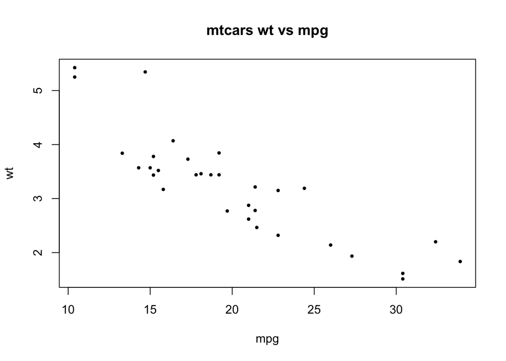

```r
mpg<-mtcars$mpg
wt<-mtcars$wt

plot(mpg, wt, pch=19, cex=0.5, main="mtcars wt vs mpg")
```

```r
#covariance analysis  "the long way" according to the equations above Chunk 8.

cov_longway<- 1 / (length(mpg)-1) * sum( (wt - mean(wt)) * (mpg-mean(mpg)))

#Covariance the easy way:
cov( wt, mpg)
```

```
## [1] -5.116685
```

Covariance says there’s a negative relationship between mpg and curbsite weight.

Pearson correlation is a normalized form of covariance, normalized by the multiplied standard deviations in paired data. The sample form and the population form for covariance (where $\sigma_{xy}$ is defined above):

$$r_{xy}=\frac{s_{xy}}{s_{x}s_{y}} ~~~~~~~~~\rho_{xy}=\frac{\sigma_{xy}}{\sigma_{x}\sigma_{y}}$$
This is the default form in the cor() function in R, method=“pearson”

In R, Pearson correlation can be calculated by the cor() function,(help(cor)) which defaults to the Pearson method. The assumptions of Pearson’s method are:

- continuous
- linear
- normally distributed
- paired correctly (old faithful data is obviously paired by observation)
- no extreme outliers
- linear
- have equal variance (homoscedastic – more on that next week)

```r
library(corrgram)

mpg<-mtcars$mpg
wt<-mtcars$wt

shapiro.test(mpg)
```

```
##
##  Shapiro-Wilk normality test
##
## data:  mpg
## W = 0.94756, p-value = 0.1229
```

```r
shapiro.test(wt)
```

```
##
##  Shapiro-Wilk normality test
##
## data:  wt
## W = 0.94326, p-value = 0.09265
```

```r
#looks good!

cor(mpg, wt, method="pearson") #pearson is the default
```

```
## [1] -0.8676594
```

```r
#We can generate a p-value of correlation with cor.test():
cor.test(mpg, wt,
         method = "pearson",
         conf.level = 0.95)
```

```
##
##  Pearson's product-moment correlation
##
## data:  mpg and wt
## t = -9.559, df = 30, p-value = 1.294e-10
## alternative hypothesis: true correlation is not equal to 0
## 95 percent confidence interval:
##  -0.9338264 -0.7440872
## sample estimates:
##        cor
## -0.8676594
```

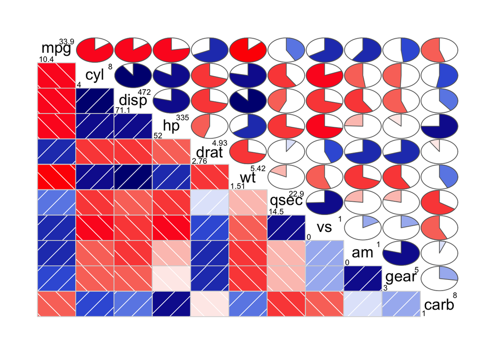

```r
#Views of correlation with corrgram():
#the numbers in the diagonal are the minimum/maximum in each variable.
corrgram(mtcars,  lower.panel=panel.shade, upper.panel=panel.pie,
         diag.panel=panel.minmax, text.panel=panel.txt)
```

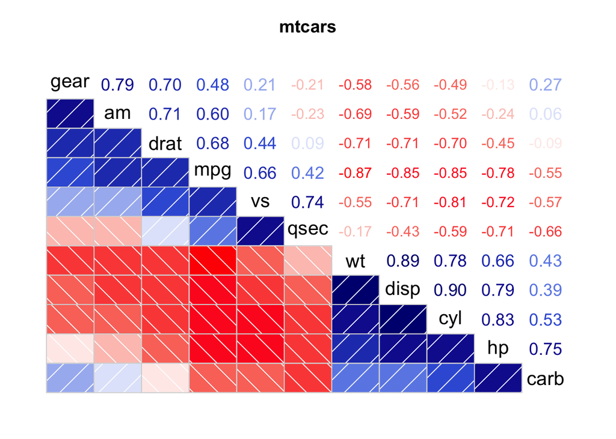

```r
#Correlation values

corrgram(mtcars, order=TRUE, upper.panel=panel.cor, main="mtcars")
```

See also this webpage for more corrgram examples:

https://cran.r-project.org/web/packages/corrgram/vignettes/corrgram_examples.html

To think about in lab:

- Generate the correlation coefficient “the long way”

# Homework Questions Week 4

## Question 1:

30 points

Given the following data:

```
##           Disease No-Disease
## Beer           39         22
## Wine           87         90
## Vodka          64        810
## Tequila        98        122
## Unexposed      12       1280
```

- 1a: Enter the data in R and print to display the data in a tabular form
- 1b: Using either of the odds ratios equations, compute the odds ratio of each exposure (drink). Edit where necessary so that the output assigns the names of the exposure in your output.
- 1c: After the data has been collected you find out that gender, age, and family history of the disease is a potential confounder, how would you control for it in the analysis?

## Question 2:

30 points

2a: For the data presented in Q1, calculate the relative risk for each exposure. 2b: Using the equation for RR, how would you expect the result to change if the number of people exposed who contracted the disease was doubled? Test your hypothesis. 2c: From the equation for the Odds Ratio, how would the odds ratio change if the number of people exposed who contracted the disease was doubled? Test your hypothesis.

## Question 3:

30 points

Code a simple function called c_inc that takes as input 2 numbers and computes the cummulative incidence of disease. Hint: see slide 32 from lecture.

## Question 4:

10 points

- 3a: Generate a correlogram with correlation values for the UK seatbelt data (see ?Seatbelts). You will need to use this form for the data: corrgram(Seatbelts[,1:8], etc etc )
- 3b: What is the greatest correlate for rear-seat passengers killed?
- 3c: What effects do the petrol prices have on death rates?